# Taxi fare

Rahil

2023-08-09

## Taxi Fare Prediction using XGBoost

### In this R Markdown document, we aim to predict taxi fare prices using a dataset obtained from Kaggle - https://www.kaggle.com/datasets/raviiloveyou/predict-taxi-fare-with-a-bigquery-ml-forecasting. The dataset contains various features such as trip_duration, passenger counts, distance_traveled, fare, tips, misc-fare and total fare We will utilize the powerful XGBoost algorithm, which is an implementation of gradient boosting, to create a predictive model.

The libraries we are going to use:

```r
shut_up <- suppressPackageStartupMessages
shut_up(library(xgboost))
shut_up(library(tidyverse))
```

```r
shut_up(library(ggplot2))
shut_up(library(plotly))
shut_up(library(dplyr))
```

### Data Exploration and Preprocessing:

```r
data_org <- read.csv("C:/Users/rahil/Downloads/archive (20)/taxi_fare/train.csv")
test_act_df <- read.csv("C:/Users/rahil/Downloads/archive (20)/taxi_fare/test.csv")
```

```r
set.seed(1234)
data_org <- data_org[sample(1:nrow(data_org)), ]
```

```r
sum(is.na(data_org))
```

```
## [1] 0
```

```r
nrow(filter(data_org, fare == 0))
```

```
## [1] 155
```

```r
df <- filter(data_org, fare != 0)
```

```r
no_need <- c('tip', 'miscellaneous_fees','total_fare')
data_org<- select(data_org, -no_need)
```

Train-Test Split: To assess the model’s performance, we will split the dataset into training and testing sets. The model will be trained on the training set and then evaluated on the test set to ensure it generalizes well to new, unseen data.

```r
data_mat <- as.matrix(data_org)

train_data <- data_mat[1:146771, ]
test_data <- data_mat[-(1:146771), ]

train_labels <- data_org$fare[1:146771]
test_labels <- data_org$fare[-(1:146771)]
```

```r
dtrain <- xgb.DMatrix(data = train_data, label= train_labels)
dtest <- xgb.DMatrix(data = test_data, label= test_labels)
```

XGBoost Model Training: Using the XGBoost package in R, we will define the model’s hyperparameters and train the algorithm on the training data. The model’s performance will be monitored during the training process.

```r
model <- xgboost(data = dtrain,    # the data
                 nround = 1000,      # max number of boosting iterations
                 objective = "reg:squarederror",
                 print_every_n = 500)
```

```r
pred <- predict(model, dtest)

err <- mean(as.numeric(pred > 0.5) != test_labels)
print(paste("test-error=", err))
```

```
## [1] "test-error= 0.999300499189215"
```

Hyperparameter Tuning: To optimize the model’s performance, we will perform hyperparameter tuning.

```r
watchlist = list(train=dtrain, test=dtest)
model_tuned <- xgb.train(data = dtrain,
                        max.depth=3,
                        eta = 0.01,
                        nthread = 3,
                        nround = 5000,
                        watchlist = watchlist,
                        objective = "reg:squarederror",
                        early_stopping_rounds = 50,
                        print_every_n = 500)
```

[output not shown]

```r
# generate predictions for our held-out testing data
pred <- predict(model_tuned, dtest)

# get & print the classification error
err <- mean(as.numeric(pred > 0.5) != test_labels)
print(paste("test-error=", err))
```

```
## [1] "test-error= 0.999284601443515"
```

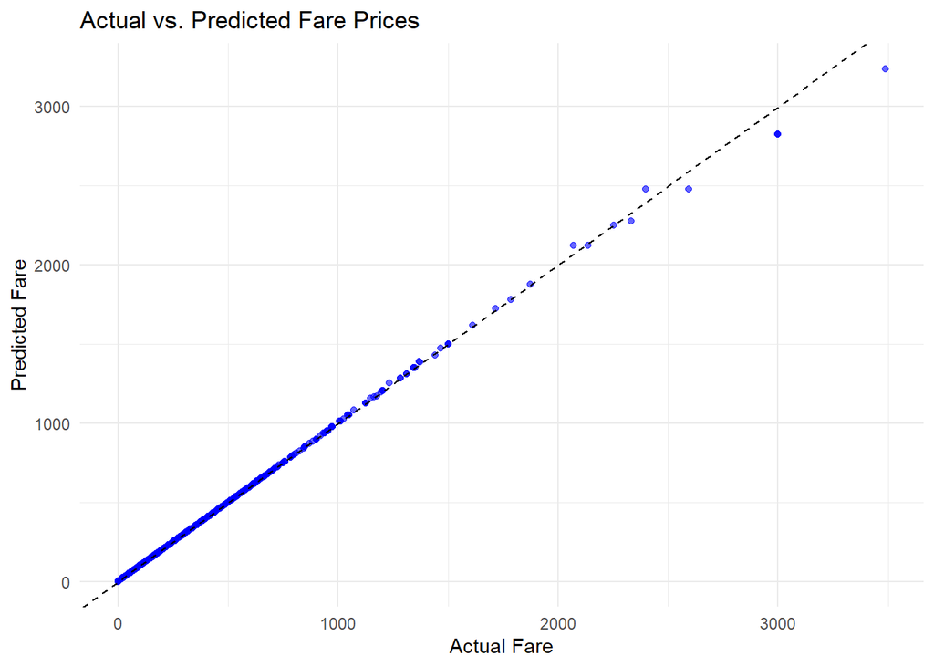

```r
# Convert the test labels and predictions to a data frame
results_df <- data.frame(Actual = test_labels, Predicted = as.numeric(pred))

# Create a scatter plot to visualize the actual vs. predicted fare values
ggplot(results_df, aes(x = Actual, y = Predicted)) +
  geom_point(color = "blue", alpha = 0.6) +  #  +   # Red for predicted values
  geom_abline(intercept = 0, slope = 1, linetype = "dashed", color = "black") +
  labs(x = "Actual Fare", y = "Predicted Fare", title = "Actual vs. Predicted Fare Prices") +
  theme_minimal()
```

```r
# Load the required library
library(randomForest)
# Train the Random Forest model
model_rf <- randomForest(
  x = train_data,
  y = train_labels,
  ntree = 500,       # Number of trees (you can adjust this value as needed)
  mtry = sqrt(ncol(train_data)),   # Number of features considered at each split (default is sqrt(p))
  importance = TRUE  # Calculate variable importance
)

# Generate predictions for the test data
pred_rf <- predict(model_rf, newdata = test_data)

# Calculate RMSE for the Random Forest predictions
test_rmse_rf <- sqrt(mean((test_labels - pred_rf)^2))
print("Test RMSE for Random Forest:")
```

```
## [1] "Test RMSE for Random Forest:"
```

```r
print(test_rmse_rf)
```

```
## [1] 11.33824
```

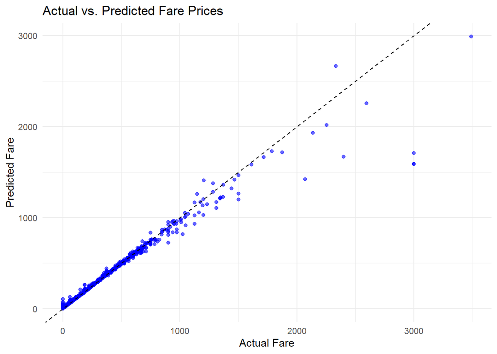

```r
# Convert the test labels and predictions to a data frame
results_df_rf <- data.frame(Actual = test_labels, Predicted = as.numeric(pred_rf))

# Create a scatter plot to visualize the actual vs. predicted fare values
ggplot(results_df_rf, aes(x = Actual, y = Predicted)) +
  geom_point(color = "blue", alpha = 0.6) +  #  +   # Red for predicted values
  geom_abline(intercept = 0, slope = 1, linetype = "dashed", color = "black") +
  labs(x = "Actual Fare", y = "Predicted Fare", title = "Actual vs. Predicted Fare Prices") +
  theme_minimal()
```